# Ancient Damage Data: R pipeline

Kushal K Dey

August 14, 2016

## Packages + Scripts

We load the packages and source the R scripts we require for running the data analysis on the Lindo2016 ancient damage data.

```r
Rcpp::sourceCpp("../../flashr/src/cloglik.cpp")
```

```
##
## > system.time(threadcheck(4))
##    user  system elapsed
##   0.010   0.006   3.009
```

```r
Rcpp::sourceCpp(("../../flashr/src/ATM.cpp"))
source("../../flashr/R/flash.R")
source("../../flashr/R/greedy.R")
source("../../flashr/R/FactorGGBar.R")
source("../../flashr/R/FactorGGplot.R")
source("../../flashr/R/flash_factor_postprocess.R")

## the above scripts will eventually be part of flashr package


source("../R/visDMsignature.R")

## will eventually be part of the damage signature package

##  The libraries we need

library(CountClust)
library(ggplot2)
library(pmsignature)
```

Some helper functions we need

```r
gsub2 <- function(pattern, replacement, x, ...) {
  for(i in 1:length(pattern))
    x <- gsub(pattern[i], replacement[i], x, ...)
  x
}
```

## Data Loading + Preprocessing

Load the Lindo 2016 Ancient Damage data. We consider first the exploratory results with the C to T damage, which is a known pattern of damage of ancient DNA over modern DNA, included.

Read the counts data of the damage signatures for each sample (modern or ancient).

```r
signature_counts <- get(load("../summary_data/signature-counts-clubbed-Lindo2016.rda"))

signature_set <- colnames(signature_counts)

## dimensions of data: nrows=number of samples
## ncols = number of damage/mutation signatures

print(dim(signature_counts))
```

```
## [1]   50 1536
```

```r
## the top corner of the counts matrix

signature_counts[1:5,1:5]
```

```
##                 AAC->AAA AAC->AAC AAC->AAG AAC->AAT AAC->ACA
## 125_all_chr.q30       38       29       31       31       35
## 158_all_chr.q30      576      270      277      233      257
## 163_all_chr.q30       10        8        6        8        2
## 167_all_chr.q30       48       35       34       33       41
## 168_all_chr.q30      983      639      724      598      688
```

We create signature pattern lists and matrices to be used later for plotting and exploration.

```r
## create a list of damage or mutation signatures

sig_split <- do.call(rbind, lapply(colnames(signature_counts), function(x) strsplit(as.character(x), split="")[[1]]))

## convert the bases to numbers

site_left_2 <- gsub2(c("A","C","G","T"), c(1,2,3,4), x=sig_split[,1])
site_left_1 <- gsub2(c("A","C","G","T"), c(1,2,3,4), x=sig_split[,2])
site_right_1 <- gsub2(c("A","C","G","T"), c(1,2,3,4), x=sig_split[,7])
site_right_2 <- gsub2(c("A","C","G","T"), c(1,2,3,4), x=sig_split[,8])

sub_pattern <- sapply(1:dim(sig_split)[1], function(x) paste(sig_split[x,3:6], collapse=""))

from = c("C->A", "C->G", "C->T", "T->A", "T->C", "T->G")
to = c(1,2,3,4,5,6)

## pattern of bases matrix

substitute <- gsub2(from, to, sub_pattern)

mutation_features <- sapply(1:dim(sig_split)[1],
                                   function(m) paste0(substitute[m], ",", site_left_2[m], ",", site_left_1[m], ",", site_right_1[m], ",", site_right_2[m]))

## matrix of mutation or damage features

mut_features_mat <- data.frame(cbind(substitute, site_left_2, site_left_1, site_right_1, site_right_2))
rownames(mut_features_mat) <- mutation_features
colnames(mut_features_mat)=NULL
mut_features_mat <- as.matrix(apply(mut_features_mat, c(1,2), function(x) as.numeric(x)))
```

## with C to T data analysis

### log CPM transformation

We convert the counts data to log CPM data by the `limma::voom` transformation.

```r
### voom transformation

voom_signature_counts <- t(limma::voom(t(signature_counts))$E);

### track the voom weights

voom_weights <- t(limma::voom(t(signature_counts))$weights);

## save the voom signature counts

write.table(voom_signature_counts, file="../../sfa_seq/sfa_inputs/sfa_input_voom_sig_with_CtoT_lindo2016.txt", row.names=FALSE,col.names=FALSE, quote=FALSE, sep="\t")
```

We start the exploratory analysis of the ancient damage data by applying the Principal Component Analysis (PCA).

### Principal Component Analysis

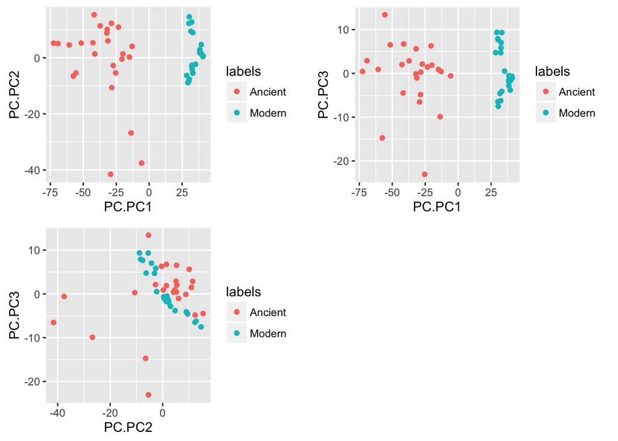

### Barchart of substitution patterns

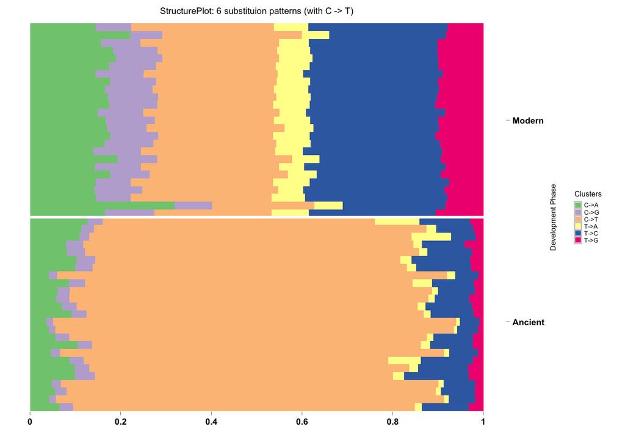

```r
sig_split <- do.call(rbind, lapply(colnames(signature_counts), function(x) strsplit(as.character(x), split="")[[1]]))

sig_split_red <- sig_split[,3:6];

substitute_sig <- sapply(1:dim(sig_split_red)[1], function(x) paste0(sig_split_red[x,], collapse=""))

normalize <- function(x) return(x/sum(x))
prop_substitute_sig <- do.call(rbind,
          lapply(1:dim(signature_counts)[1], function(x)
          normalize(tapply(signature_counts[x,], substitute_sig, sum))))

annotation <- data.frame(
  sample_id = paste0("X", c(1:NROW(prop_substitute_sig))),
  tissue_label = factor(c(rep("Ancient",25), rep("Modern",25)))
)

rownames(prop_substitute_sig) <- annotation$sample_id;

StructureGGplot(omega = prop_substitute_sig,
                annotation = annotation,
                palette = RColorBrewer::brewer.pal(8, "Accent"),
                yaxis_label = "Development Phase",
                order_sample = FALSE,
                figure_title = paste0("StructurePlot: 6 substituion patterns (with C -> T)"),
                axis_tick = list(axis_ticks_length = .1,
                                 axis_ticks_lwd_y = .1,
                                 axis_ticks_lwd_x = .1,
                                 axis_label_size = 7,
                                 axis_label_face = "bold"))
```

### Factor Loadings Results (type-known)

We now load the FLASH results for the data.

```r
ll <- flashpool(voom_signature_counts, K=10,
                 tol=1e-3, maxiter_r1 = 100,
                 partype="known",
                 sigmae2_true = 1/(voom_weights),
                 nonnegative=FALSE)
```

```
## We are at iteration 1
## We are at iteration 2
## We are at iteration 3
## We are at iteration 4
## We are at iteration 5
## We are at iteration 6
## We are at iteration 7
## We are at iteration 8
## We are at iteration 9
## We are at iteration 10
```

```r
postprocess_ll <- flash_factor_postprocess(ll$l,ll$f, voom_signature_counts)
pve_percentage <- c("", paste0(": PVE : ", round(postprocess_ll$PVE*100,1), "%"))
zero_pve <- max(which(postprocess_ll$PVE > 0))
ll$l <- ll$l[,1:(1+zero_pve)]
ll$f <- ll$f[,1:(1+zero_pve)]
```

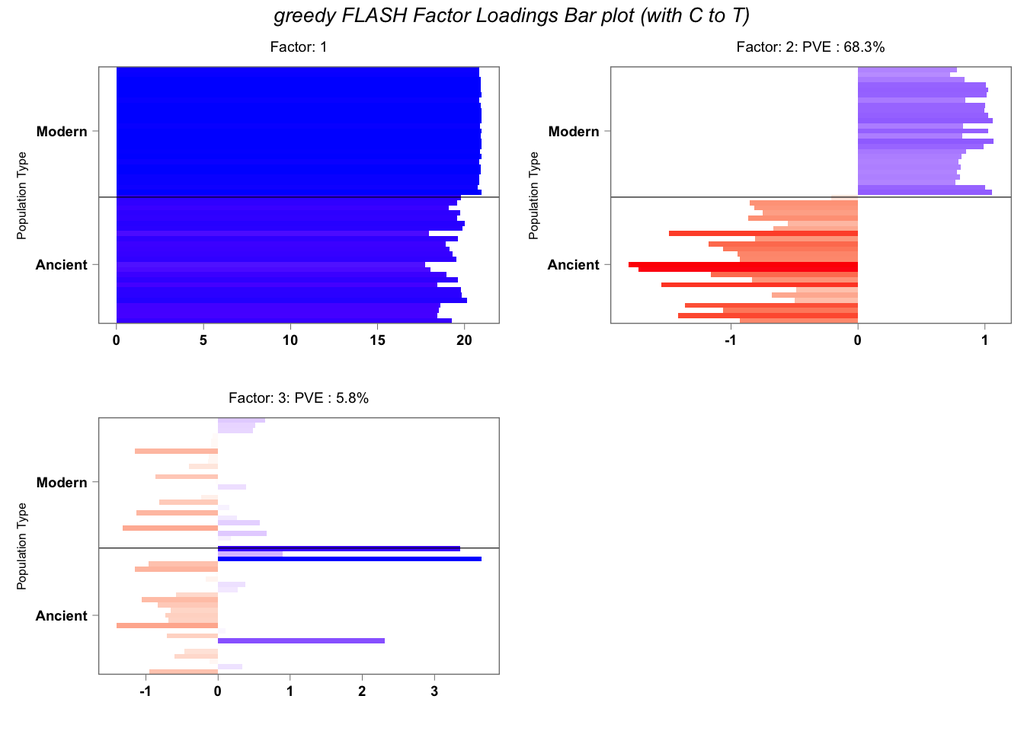

```r
annotation <- data.frame(
  sample_id = paste0("X", c(1:NROW(ll$l))),
  label = factor(c(rep("Ancient",25), rep("Modern",25)))
)

rownames(ll$l) <- paste0("X", c(1:NROW(ll$l)));

FactorGGBar(loadings = ll$l,
            annotation = annotation,
            palette = list("mid"="white",
                           "low"="red",
                           "high"="blue",
                           "midpoint"=0),
             yaxis_label = "Population Type",
             figure_title = " ",
             axis_tick = list(axis_ticks_length = .1,
                              axis_ticks_lwd_y = .1,
                              axis_ticks_lwd_x = .1,
                              axis_label_size = 7,
                              axis_label_face = "bold"),
            legend_labels = pve_percentage[1:(zero_pve+1)],
            scale=TRUE,
            panel=list(panel_rows=2,
                       panel_title="greedy FLASH Factor Loadings Bar plot (with C to T)",
                       panel_title_fontsize=10,
                       panel_title_font=3))
```

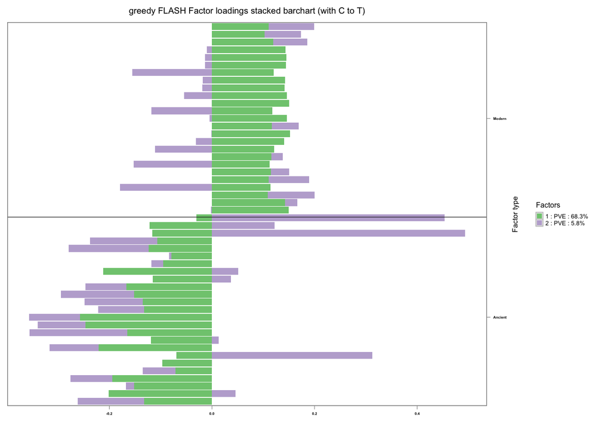

```r
FactorGGplot(loadings = ll$l[,-1],
             annotation = annotation,
             palette = c( RColorBrewer::brewer.pal(8, "Accent"),
                          RColorBrewer::brewer.pal(4, "Spectral")),
             figure_title = "greedy FLASH Factor loadings stacked barchart (with C to T)",
             yaxis_label = "Factor type",
             order_sample = FALSE,
             sample_order_decreasing = FALSE,
             split_line = list(split_lwd = 0.2,
                               split_col = "black"),
             plot_labels = TRUE,
             legend_labels = pve_percentage[-1],
             scale=FALSE,
             axis_tick = list(axis_ticks_length = .1,
                              axis_ticks_lwd_y = .1,
                              axis_ticks_lwd_x = .1,
                              axis_label_size = 3,
                              axis_label_face = "bold"))
```

```r
rownames(ll$f) <- signature_set
ll_f_scale <- apply(ll$f[,-1],2,function(x)
                                  {
                                      if(sd(x)!=0) {return (x/sd(x))}
                                      else {return (x)}
    })

normalize <- function(x) { return (x/sum(x))}

abs_f_scale <- apply(ll_f_scale,2,function(x) normalize(abs(x)))
indices <- CountClust::ExtractTopFeatures(abs_f_scale, top_features=10, method="poisson", options="min")
imp_features <- apply(indices, c(1,2), function(x) signature_set[x])

imp_features
```

```
##      [,1]       [,2]       [,3]       [,4]       [,5]       [,6]
## [1,] "TTC->TGG" "ATC->TGG" "CCC->TAC" "ACC->TGT" "CTT->ATG" "GGT->GAT"
## [2,] "AAT->AGT" "TGT->AAA" "AAT->AGA" "AGT->AAA" "CGC->GCG" "AAT->AAA"
##      [,7]       [,8]       [,9]       [,10]
## [1,] "TTC->TCG" "GTC->TGT" "GAC->TCA" "TCC->TGT"
## [2,] "CGC->ACG" "AAT->ATA" "GAT->AAA" "GCT->AAA"
```

### Factor Loadings Results (with type-constant)

We now load the FLASH results for the data.

```r
ll <- flashpool(voom_signature_counts, K=10,
                 tol=1e-3, maxiter_r1 = 100,
                 partype="constant",
                 nonnegative=FALSE)
```

```
## We are at iteration 1
## We are at iteration 2
## We are at iteration 3
## We are at iteration 4
## We are at iteration 5
## We are at iteration 6
## We are at iteration 7
## We are at iteration 8
## We are at iteration 9
## We are at iteration 10
```

```r
postprocess_ll <- flash_factor_postprocess(ll$l,ll$f, voom_signature_counts)
pve_percentage <- c("", paste0(": PVE : ", round(postprocess_ll$PVE*100,1), "%"))
```

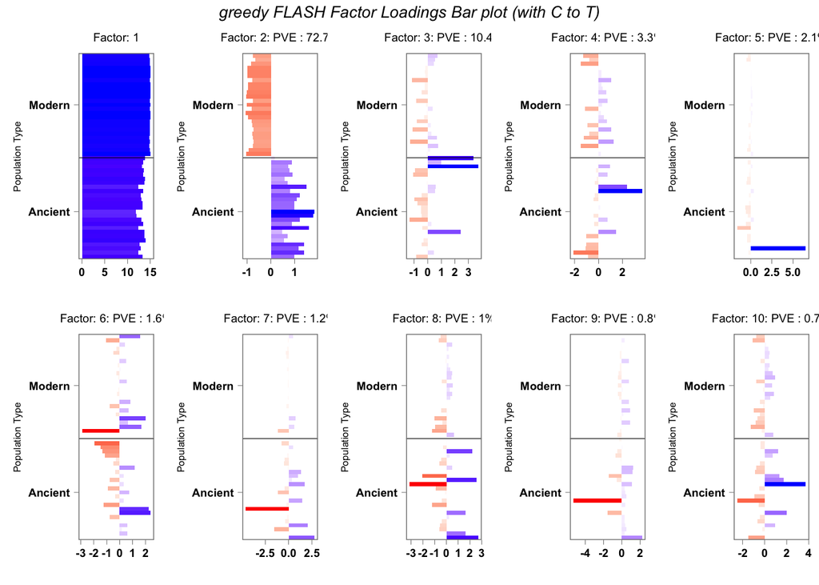

```r
library(ggplot2)
annotation <- data.frame(
  sample_id = paste0("X", c(1:NROW(ll$l))),
  label = factor(c(rep("Ancient",25), rep("Modern",25)))
)

rownames(ll$l) <- paste0("X", c(1:NROW(ll$l)));

FactorGGBar(loadings = ll$l,
            annotation = annotation,
            palette = list("mid"="white",
                           "low"="red",
                           "high"="blue",
                           "midpoint"=0),
             yaxis_label = "Population Type",
             figure_title = " ",
             axis_tick = list(axis_ticks_length = .1,
                              axis_ticks_lwd_y = .1,
                              axis_ticks_lwd_x = .1,
                              axis_label_size = 7,
                              axis_label_face = "bold"),
            legend_labels = pve_percentage,
            scale=TRUE,
            panel=list(panel_rows=2,
                       panel_title="greedy FLASH Factor Loadings Bar plot (with C to T)",
                       panel_title_fontsize=10,
                       panel_title_font=3))
```

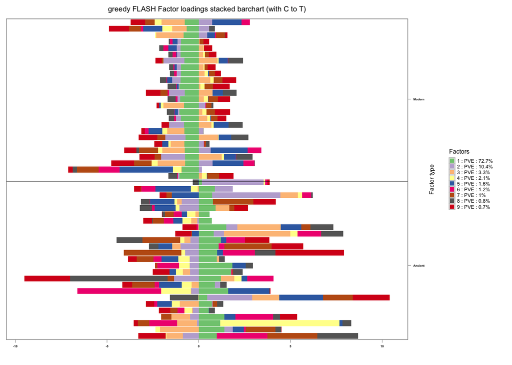

```r
FactorGGplot(loadings = ll$l[,-1],
             annotation = annotation,
             palette = c( RColorBrewer::brewer.pal(8, "Accent"),
                          RColorBrewer::brewer.pal(4, "Spectral")),
             figure_title = "greedy FLASH Factor loadings stacked barchart (with C to T)",
             yaxis_label = "Factor type",
             order_sample = FALSE,
             sample_order_decreasing = TRUE,
             split_line = list(split_lwd = 0.2,
                               split_col = "black"),
             plot_labels = TRUE,
             legend_labels = pve_percentage[-1],
             scale=TRUE,
             axis_tick = list(axis_ticks_length = .1,
                              axis_ticks_lwd_y = .1,
                              axis_ticks_lwd_x = .1,
                              axis_label_size = 3,
                              axis_label_face = "bold"))
```

```r
rownames(ll$f) <- signature_set
ll_f_scale <- apply(ll$f[,-1],2,function(x)
                                  {
                                      if(sd(x)!=0) {return (x/sd(x))}
                                      else {return (x)}
    })

normalize <- function(x) { return (x/sum(x))}

abs_f_scale <- apply(ll_f_scale,2,function(x) normalize(abs(x)))
indices <- CountClust::ExtractTopFeatures(abs_f_scale, top_features=10, method="poisson", options="min")
imp_features <- apply(indices, c(1,2), function(x) signature_set[x])

imp_features
```

```
##       [,1]       [,2]       [,3]       [,4]       [,5]       [,6]
##  [1,] "GTC->TCA" "GTC->TCT" "TCC->TTC" "CTC->TCT" "ACC->TTC" "CTC->TCA"
##  [2,] "AAT->ATT" "AAT->AAT" "TAT->AAC" "TAT->AAT" "TAT->AGT" "AAC->AAA"
##  [3,] "TAT->CTA" "GCT->AAG" "TTT->CCA" "CGC->AGC" "GGT->AAC" "GAT->ACC"
##  [4,] "TGC->ATA" "TGC->GAG" "CTC->AGA" "GCT->CAC" "TTC->GCC" "GAT->CAG"
##  [5,] "GTC->ACT" "CCC->ATG" "GCC->ACA" "TTC->ACG" "GCC->ATG" "CAT->CCT"
##  [6,] "TCT->GGG" "CTT->AGT" "CGT->AAT" "TAC->GAT" "GGT->GTT" "AAT->GGA"
##  [7,] "GCT->GGG" "ATT->GGG" "GAT->GTT" "AAT->GCG" "ACT->GGG" "GCT->GGT"
##  [8,] "ATT->AGC" "ACT->ATA" "AAT->GCC" "CGT->GAT" "CTT->ATA" "TCT->ACC"
##  [9,] "ATT->ACC" "ACC->GAT" "TTT->ATT" "ATT->CGC" "GTC->GAT" "GTT->ATG"
##       [,7]       [,8]       [,9]       [,10]
##  [1,] "CTC->TTG" "TTC->TCG" "TCC->TTG" "ACC->TCC"
##  [2,] "AAT->AAA" "AAT->AGT" "CAT->AAT" "TAC->AAA"
##  [3,] "TAT->CTT" "TGC->GGC" "CGT->CGC" "GCC->GGA"
##  [4,] "AGT->GTT" "AGC->GAA" "ATC->ACT" "CGC->GCA"
##  [5,] "GCC->ATC" "TCC->ACT" "CAC->ATG" "GCC->ATT"
##  [6,] "AAT->GCA" "TAT->GAA" "AAC->GTC" "TGT->ACC"
##  [7,] "AGT->GGG" "TGT->GGA" "GCT->GTA" "TGT->GCC"
##  [8,] "TAT->AGA" "TTT->ATG" "TTT->ACT" "GAT->ATT"
##  [9,] "GCT->AAT" "GTC->GTA" "GCT->ACT" "TCT->AGC"
```

### Sparse Factor Analysis

We now apply SFA and compare the results.

```r
# ./sfa_mac -gen ../../sfa_inputs/voom_sig_with_CtoT_lindo2016.txt -g 50 -n 1536 -k 10 -iter 500 -r 800 -o ../../sfa_outputs/Lindo2016/without_CtoT/voom_lindo_without_CtoT
#  ./sfa_mac -gen ../../sfa_inputs/sfa_input_voom_sig_with_CtoT_lindo2016.txt -g 50 -n 1536 -k 10 -iter 500 -r 800  -o ../../sfa_outputs/Lindo2016/with_CtoT/voom_lindo_with_CtoT
```

```r
loadings <- read.table("../utilities/sfa_Lindo2016/with_CtoT/voom_lindo_with_CtoT_lambda.out")
factors <- read.table("../utilities/sfa_Lindo2016/with_CtoT/voom_lindo_with_CtoT_F.out")
ll <- list("l"=loadings, "f"=t(factors))

postprocess_ll <- flash_factor_postprocess(ll$l,ll$f, voom_signature_counts)
pve_percentage <- c("", paste0(": PVE : ", round(postprocess_ll$PVE*100,1), "%"))
```

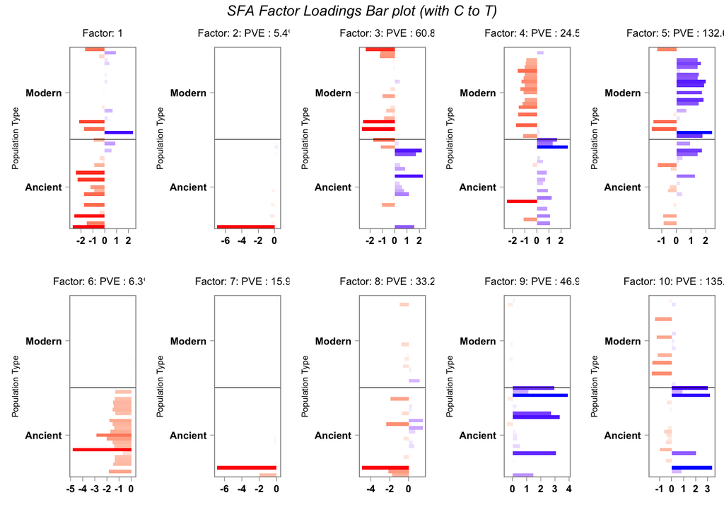

```r
library(ggplot2)
annotation <- data.frame(
  sample_id = paste0("X", c(1:NROW(ll$l))),
  label = factor(c(rep("Ancient",25), rep("Modern",25)))
)

rownames(ll$l) <- paste0("X", c(1:NROW(ll$l)));

FactorGGBar(loadings = ll$l,
             annotation = annotation,
            palette = list("mid"="white",
                           "low"="red",
                           "high"="blue",
                           "midpoint"=0),
             yaxis_label = "Population Type",
             figure_title = " ",
             axis_tick = list(axis_ticks_length = .1,
                              axis_ticks_lwd_y = .1,
                              axis_ticks_lwd_x = .1,
                              axis_label_size = 7,
                              axis_label_face = "bold"),
            legend_labels = pve_percentage,
            scale=TRUE,
            panel=list(panel_rows=2,
                       panel_title="SFA Factor Loadings Bar plot (with C to T)",
                       panel_title_fontsize=10,
                       panel_title_font=3))
```

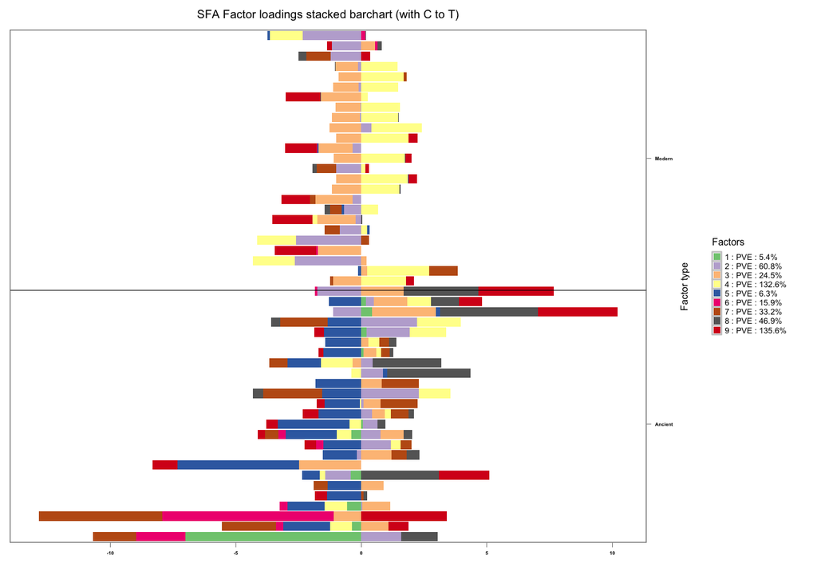

```r
FactorGGplot(loadings = ll$l[,-1],
             annotation = annotation,
             palette = c( RColorBrewer::brewer.pal(8, "Accent"),
                          RColorBrewer::brewer.pal(4, "Spectral")),
             figure_title = "SFA Factor loadings stacked barchart (with C to T)",
             yaxis_label = "Factor type",
             order_sample = FALSE,
             sample_order_decreasing = TRUE,
             split_line = list(split_lwd = 0.2,
                               split_col = "black"),
             plot_labels = TRUE,
             legend_labels = pve_percentage[-1],
             scale=TRUE,
             axis_tick = list(axis_ticks_length = .1,
                              axis_ticks_lwd_y = .1,
                              axis_ticks_lwd_x = .1,
                              axis_label_size = 3,
                              axis_label_face = "bold"))
```

```r
rownames(ll$f) <- signature_set
ll_f_scale <- apply(ll$f[,-1],2,function(x)
                                  {
                                      if(sd(x)!=0) {return (x/sd(x))}
                                      else {return (x)}
    })

normalize <- function(x) { return (x/sum(x))}

abs_f_scale <- apply(ll_f_scale,2,function(x) normalize(abs(x)))
indices <- CountClust::ExtractTopFeatures(abs_f_scale, top_features=10, method="poisson", options="min")
imp_features <- apply(indices, c(1,2), function(x) signature_set[x])

imp_features
```

```
##       [,1]       [,2]       [,3]       [,4]       [,5]       [,6]
##  [1,] "GGT->ATG" "CGT->AGC" "CGT->ATC" "GAT->ATG" "CGT->ACG" "TCC->GTG"
##  [2,] "TAT->CAT" "ATT->GAA" "GTT->AAT" "TAT->AGC" "TAT->ACT" "ATT->AGT"
##  [3,] "AAT->GGA" "CGT->GAA" "AAC->ATG" "GGT->GTT" "AAT->GCA" "TTT->GCA"
##  [4,] "TCT->GCT" "CCT->ACT" "GTT->ACG" "GTT->ACC" "TTT->ACG" "GCC->GCA"
##  [5,] "GTC->TTC" "GTC->TTT" "TTC->TTG" "GTC->TTG" "GTC->TTA" "TTC->TTC"
##  [6,] "CGC->GCA" "GCC->ACC" "GCC->AGC" "TCC->AGC" "CGC->GGC" "ATC->ACG"
##  [7,] "AGT->GGG" "GGT->GGA" "AGT->GGC" "GGT->GGG" "ACT->GGG" "CGT->GGT"
##  [8,] "AAT->ACG" "CAT->ACG" "TGT->AAA" "AGT->AAA" "GGT->AAA" "AGT->AAG"
##  [9,] "GAC->GGC" "GGT->CTG" "GAC->GGT" "TCT->CGC" "CCT->CGA" "TGC->GGG"
##       [,7]       [,8]       [,9]       [,10]
##  [1,] "GCT->AAG" "CCT->AGC" "TAT->ACG" "TAC->GAT"
##  [2,] "ACT->ATA" "ATT->GAT" "TCT->ATA" "CGT->ATA"
##  [3,] "GGC->ATA" "ATC->AGG" "CAC->ACT" "GTT->GAA"
##  [4,] "CTC->GAG" "CCC->GAT" "GCC->GTA" "TTC->GCG"
##  [5,] "TTC->TTA" "ATC->TTG" "CTC->TTG" "GCC->TTT"
##  [6,] "CGC->AGC" "CTC->GGC" "GCC->ACG" "AAC->AGC"
##  [7,] "AGT->GGA" "TAT->GGG" "GGT->GAG" "TGT->GGG"
##  [8,] "AAT->AGT" "AAT->AAG" "AAT->AAC" "AAT->AGG"
##  [9,] "AGC->GAG" "CCC->GCT" "AAT->GCC" "GAT->CGG"
```

### Penalized Matrix Decomposition

```r
ll_pmd <- PMA::PMD(voom_signature_counts,
               type="standard",
               K=10)
```

```
## 123456789101112131415
## 1234567891011121314151617181920
## 1234567891011121314151617181920
## 1234567891011121314151617181920
## 1234567891011121314151617181920
## 1234567891011121314151617181920
## 1234567891011121314151617181920
## 1234567891011121314151617181920
## 12345678910111213141516171819
## 1234567891011121314151617181920
```

```r
ll <- list("l"=ll_pmd$u, "f"=ll_pmd$v)
postprocess_ll <- flash_factor_postprocess(ll$l,ll$f, voom_signature_counts)
pve_percentage <- c("", paste0(": PVE : ", round(postprocess_ll$PVE*100,1), "%"))
```

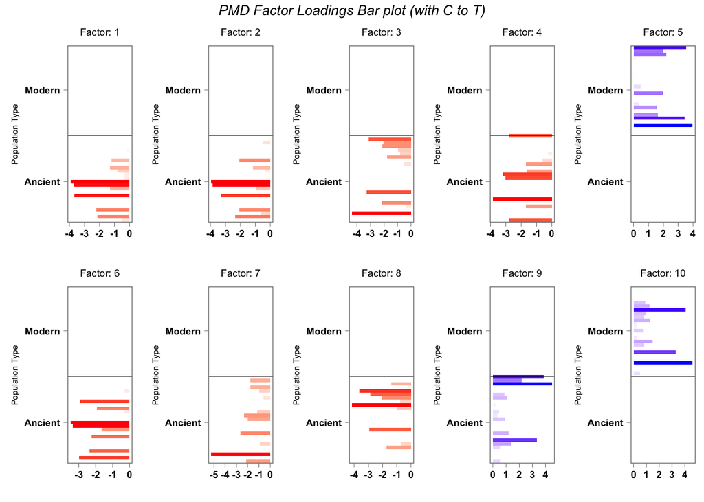

```r
library(ggplot2)
annotation <- data.frame(
  sample_id = paste0("X", c(1:NROW(ll$l))),
  label = factor(c(rep("Ancient",25), rep("Modern",25)))
)

rownames(ll$l) <- paste0("X", c(1:NROW(ll$l)));

FactorGGBar(loadings = ll$l,
             annotation = annotation,
            palette = list("mid"="white",
                           "low"="red",
                           "high"="blue",
                           "midpoint"=0),
             yaxis_label = "Population Type",
             figure_title = " ",
             axis_tick = list(axis_ticks_length = .1,
                              axis_ticks_lwd_y = .1,
                              axis_ticks_lwd_x = .1,
                              axis_label_size = 7,
                              axis_label_face = "bold"),
            scale=TRUE,
            panel=list(panel_rows=2,
                       panel_title="PMD Factor Loadings Bar plot (with C to T)",
                       panel_title_fontsize=10,
                       panel_title_font=3))
```

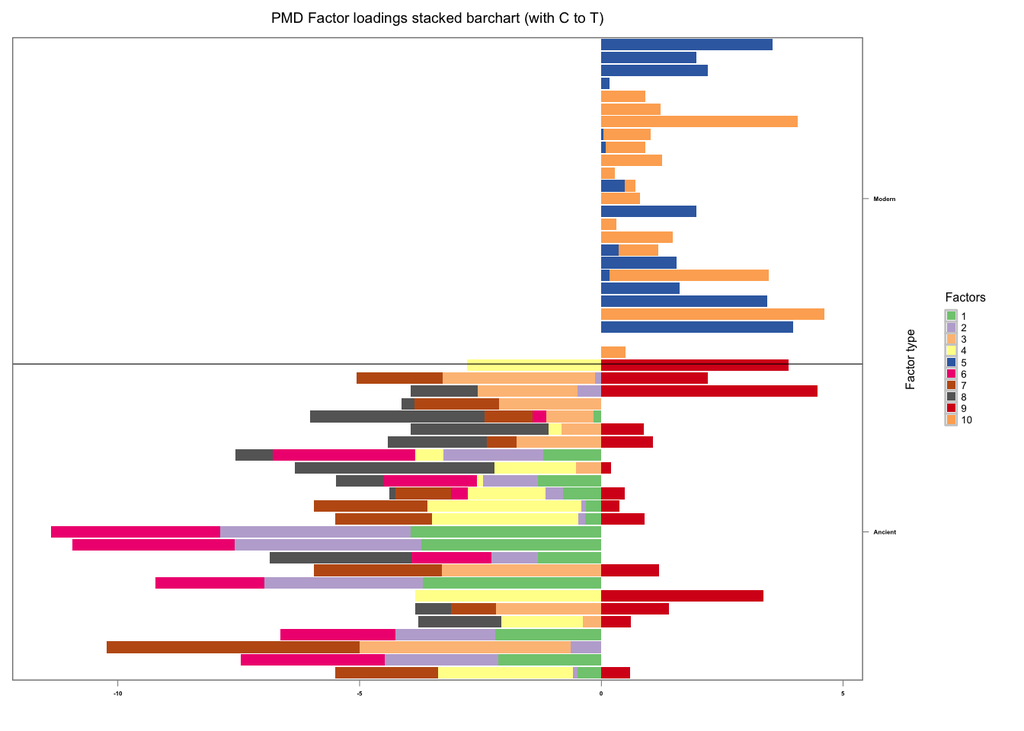

```r
FactorGGplot(loadings = ll$l,
             annotation = annotation,
             palette = c( RColorBrewer::brewer.pal(8, "Accent"),
                          RColorBrewer::brewer.pal(4, "Spectral")),
             figure_title = "PMD Factor loadings stacked barchart (with C to T)",
             yaxis_label = "Factor type",
             order_sample = FALSE,
             sample_order_decreasing = TRUE,
             split_line = list(split_lwd = 0.2,
                               split_col = "black"),
             plot_labels = TRUE,
             legend_labels = "",
             scale=TRUE,
             axis_tick = list(axis_ticks_length = .1,
                              axis_ticks_lwd_y = .1,
                              axis_ticks_lwd_x = .1,
                              axis_label_size = 3,
                              axis_label_face = "bold"))
```

```r
rownames(ll$f) <- signature_set
ll_f_scale <- apply(ll$f,2,function(x)
                                  {
                                      if(sd(x)!=0) {return (x/sd(x))}
                                      else {return (x)}
    })

normalize <- function(x) { return (x/sum(x))}

abs_f_scale <- apply(ll$f,2,function(x) normalize(abs(x)))
indices <- CountClust::ExtractTopFeatures(abs_f_scale, top_features=10, method="poisson", options="min")
imp_features <- apply(indices, c(1,2), function(x) signature_set[x])

imp_features
```

```
##       [,1]       [,2]       [,3]       [,4]       [,5]       [,6]
##  [1,] "GTT->AAT" "CAT->ATA" "GAT->ATG" "TAT->AGG" "ATT->AAT" "CGT->AAA"
##  [2,] "TCT->ACT" "TTT->ATT" "CCT->ATT" "CAT->ACC" "GCT->ACA" "TGT->ATT"
##  [3,] "GTT->AGC" "GCC->GTA" "GAT->GCG" "CGC->GTT" "GTC->TTT" "TTC->TTA"
##  [4,] "GCT->GAG" "CGT->ATC" "CGT->GTG" "TTT->GAG" "CTC->TGA" "ATC->GCG"
##  [5,] "AAC->AAC" "AAC->AAG" "AAC->AAT" "AAC->ACA" "AAT->CAC" "AAT->CCT"
##  [6,] "AAC->GAC" "AAC->GAT" "AAC->GGT" "AAC->GTG" "AAC->GTT" "AAT->AGA"
##  [7,] "ACT->AGA" "AGT->AGA" "CTC->GAG" "GAC->GAT" "TTC->TTT" "GAT->ACA"
##  [8,] "AGT->ACT" "TCT->AGA" "AAT->GCT" "CCC->TCG" "GAT->GTC" "AAT->GGC"
##  [9,] "AAT->CCG" "ACC->AGC" "ACT->GTC" "AGC->GGG" "CAC->GCT" "CAT->GTT"
## [10,] "ACC->AGA" "ACC->AGG" "ACT->CAC" "ACT->CCC" "ACT->CCT" "ACT->CGC"
##       [,7]       [,8]       [,9]       [,10]
##  [1,] "CGT->GAT" "CAT->ACG" "TAT->ACC" "GAT->ATA"
##  [2,] "AAT->AAT" "TTT->ATG" "AGC->GAT" "TTT->ATC"
##  [3,] "GAC->TTT" "ATC->TTT" "TTC->TTG" "ACC->TTT"
##  [4,] "CGT->GTA" "AGC->TCT" "GTC->TAG" "CTC->TAC"
##  [5,] "ACC->AAA" "ATT->CAT" "ATT->CGT" "ATT->CTT"
##  [6,] "AAT->AGG" "AAT->GAA" "ACC->GAA" "ACC->GAC"
##  [7,] "GAT->ACT" "TTT->AAC" "AAT->ATG" "CTT->AAA"
##  [8,] "CTT->GAG" "CTT->GAT" "ATT->GAT" "AAT->GTC"
##  [9,] "CCC->GAC" "CCC->GTG" "CCT->ACC" "CCT->GTC"
## [10,] "ACT->CTC" "ACT->CTG" "AGC->ACA" "AGT->CCG"
```

### CountCluster application

```r
topics_clus <- get(load("../rda/CountClust_output_Lindo2016_with_C_to_T.rda"))
```

#### K=2

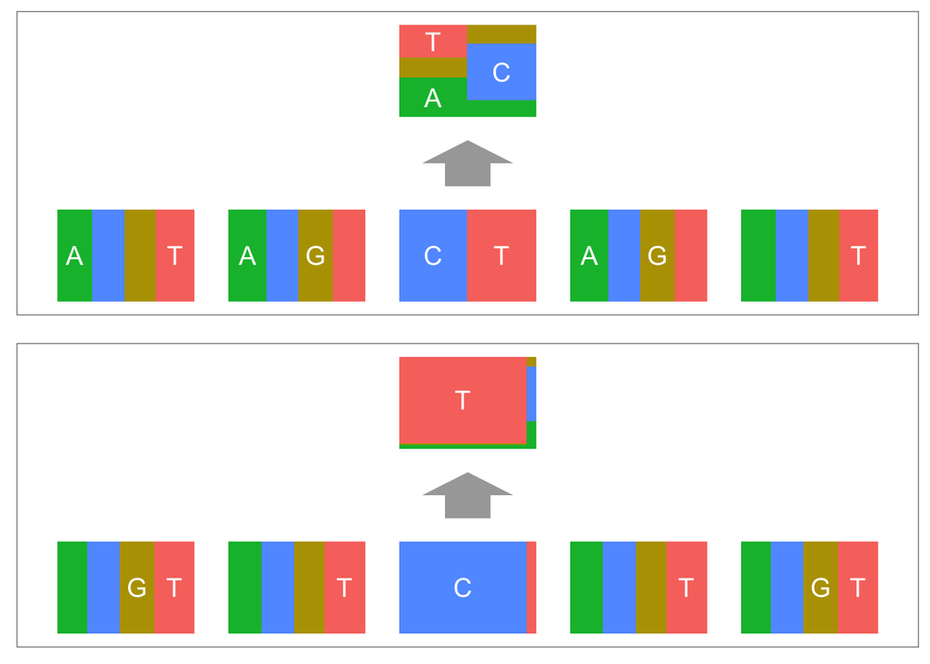

```r
theta <- topics_clus$clust_2$theta;
omega <- topics_clus$clust_2$omega

isBG <- TRUE
numBases <- 5
type <- "independent"
flankingBasesNum = as.integer(numBases)
trDir <- FALSE
sample_names <- rownames(signature_counts)
fdim <- c(6, rep(4, numBases - 1), rep(2, as.integer(trDir)))


K <- dim(omega)[2]
F <- array(0, c(K, length(fdim), max(fdim)))
for(k in 1:K){
  for(kk in 1:length(fdim)){
    temp <- tapply(theta[,k], mut_features_mat[,kk], sum)
    F[k,kk,as.numeric(names(temp))] <- as.numeric(temp)
  }
}


Param <- new(Class = "EstimatedParameters",
           type = type,
           flankingBasesNum = flankingBasesNum,
           transcriptionDirection = trDir,
           possibleFeatures = as.integer(fdim),
           sampleList = sample_names,
           signatureNum = as.integer(K),
           isBackGround = isBG,
           signatureFeatureDistribution = F,
           sampleSignatureDistribution = omega,
           loglikelihood = -100000)

graphList <- list(mode="vector")
graphList[[1]] <- visPMSignature(Param, 1)
graphList[[2]] <- visPMSignature(Param, 2)
library(grid)
library(gridExtra)
do.call("grid.arrange",
          args = list(grobs=graphList,
                      ncol = 1,
                      nrow = 2))
```

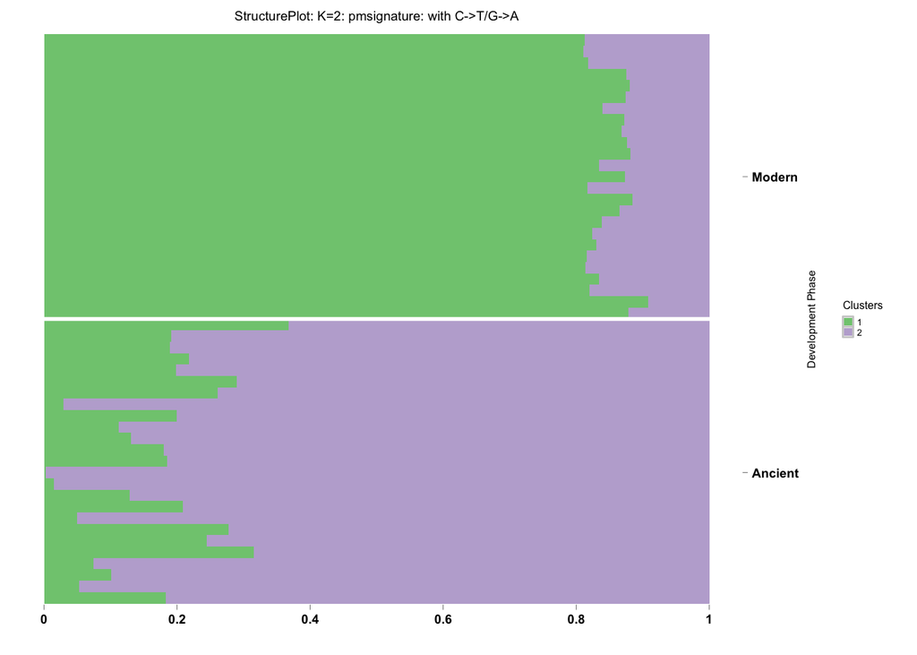

```r
omega <- slot(Param, "sampleSignatureDistribution")
library(CountClust)
annotation <- data.frame(
  sample_id = paste0("X", c(1:NROW(omega))),
  tissue_label = factor(c(rep("Ancient",25), rep("Modern",25)))
)

rownames(omega) <- annotation$sample_id;

StructureGGplot(omega = omega,
                annotation = annotation,
                palette = RColorBrewer::brewer.pal(8, "Accent"),
                yaxis_label = "Development Phase",
                order_sample = FALSE,
                figure_title = paste0("StructurePlot: K=", dim(omega)[2],": pmsignature: with C->T/G->A"),
                axis_tick = list(axis_ticks_length = .1,
                                 axis_ticks_lwd_y = .1,
                                 axis_ticks_lwd_x = .1,
                                 axis_label_size = 7,
                                 axis_label_face = "bold"))
```

```r
apply(ExtractTopFeatures(theta, top_features = 10, method="poisson", options="min"), c(1,2), function(x) signature_set[x])
```

```
##      [,1]       [,2]       [,3]       [,4]       [,5]       [,6]
## [1,] "AAC->AAA" "TTT->GTT" "TTT->CTT" "TAT->CAT" "AAT->ATT" "TAT->CTT"
## [2,] "TTC->TTG" "GTC->TTT" "GTC->TTG" "GTC->TTC" "TTC->TTC" "TTC->TTT"
##      [,7]       [,8]       [,9]       [,10]
## [1,] "TTT->CAT" "TTT->ATT" "CTT->GTC" "TAT->CAA"
## [2,] "CTC->TTT" "TTC->TTA" "ATC->TTT" "CTC->TTG"
```

#### K=3

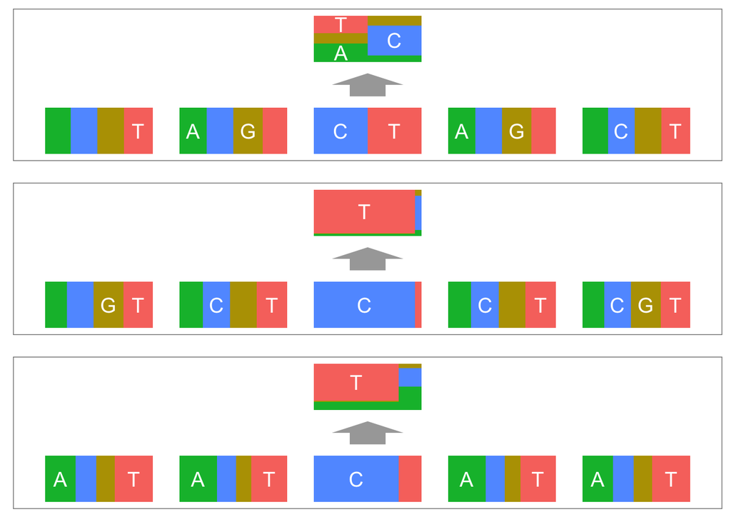

```r
theta <- topics_clus$clust_3$theta;
omega <- topics_clus$clust_3$omega

isBG <- TRUE
numBases <- 5
type <- "independent"
flankingBasesNum = as.integer(numBases)
trDir <- FALSE
fdim <- c(6, rep(4, numBases - 1), rep(2, as.integer(trDir)))
sample_names <- rownames(signature_counts)

K <- dim(omega)[2]
F <- array(0, c(K, length(fdim), max(fdim)))
for(k in 1:K){
  for(kk in 1:length(fdim)){
    temp <- tapply(theta[,k], mut_features_mat[,kk], sum)
    F[k,kk,as.numeric(names(temp))] <- as.numeric(temp)
  }
}

Param <- new(Class = "EstimatedParameters",
           type = type,
           flankingBasesNum = flankingBasesNum,
           transcriptionDirection = trDir,
           possibleFeatures = as.integer(fdim),
           sampleList = sample_names,
           signatureNum = as.integer(K),
           isBackGround = isBG,
           signatureFeatureDistribution = F,
           sampleSignatureDistribution = omega,
           loglikelihood = -100000)

graphList <- list(mode="vector")
graphList[[1]] <- visPMSignature(Param, 1)
graphList[[2]] <- visPMSignature(Param, 2)
graphList[[3]] <- visPMSignature(Param, 3)
library(grid)
library(gridExtra)
do.call("grid.arrange",
          args = list(grobs=graphList,
                      ncol = 1,
                      nrow = 3))
```

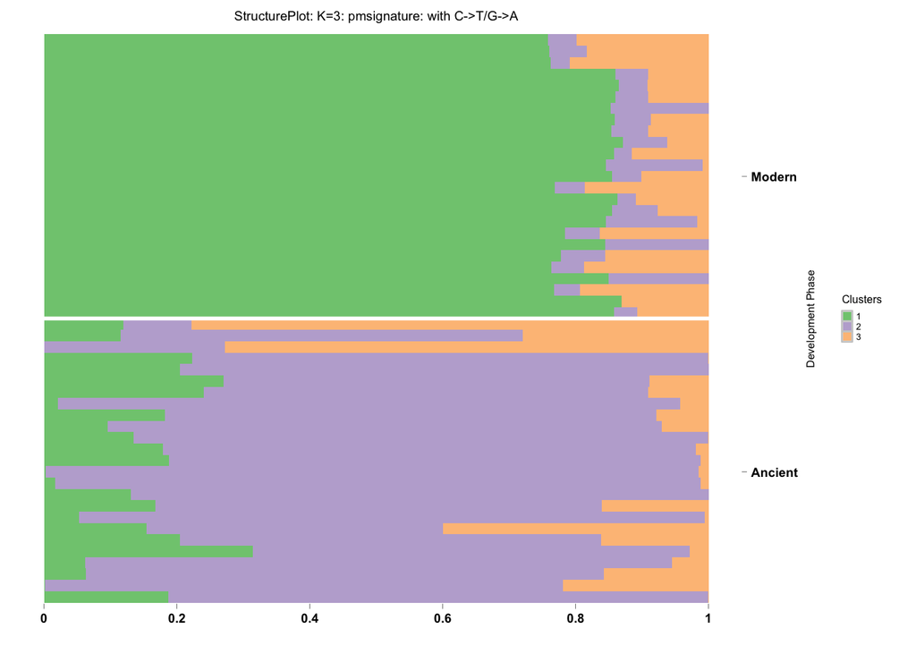

```r
omega <- slot(Param, "sampleSignatureDistribution")
library(CountClust)
annotation <- data.frame(
  sample_id = paste0("X", c(1:NROW(omega))),
  tissue_label = factor(c(rep("Ancient",25), rep("Modern",25)))
)

rownames(omega) <- annotation$sample_id;

StructureGGplot(omega = omega,
                annotation = annotation,
                palette = RColorBrewer::brewer.pal(8, "Accent"),
                yaxis_label = "Development Phase",
                order_sample = FALSE,
                figure_title = paste0("StructurePlot: K=", dim(omega)[2],": pmsignature: with C->T/G->A"),
                axis_tick = list(axis_ticks_length = .1,
                                 axis_ticks_lwd_y = .1,
                                 axis_ticks_lwd_x = .1,
                                 axis_label_size = 7,
                                 axis_label_face = "bold"))
```

```r
apply(ExtractTopFeatures(theta, top_features = 10, method="poisson", options="min"), c(1,2), function(x) signature_set[x])
```

```
##      [,1]       [,2]       [,3]       [,4]       [,5]       [,6]
## [1,] "GGT->GGG" "GGT->CGG" "CTT->GTC" "CCT->CGG" "GGT->CCC" "GGT->CAG"
## [2,] "GTC->TGG" "GGC->TTG" "GGC->TGG" "GGC->TTC" "GTC->TCC" "CTC->TGG"
## [3,] "AAT->AAA" "AAT->AGT" "TGT->AAA" "TAC->TAT" "AGT->AAA" "TTC->TTT"
##      [,7]       [,8]       [,9]       [,10]
## [1,] "GGT->CCT" "CCT->CTG" "GGT->CGT" "GAT->CGG"
## [2,] "CCC->TTG" "GTC->TGC" "GGC->TCT" "TCC->TGG"
## [3,] "AAT->ATA" "ATT->AAA" "AAT->AGA" "AAT->AAT"
```

#### K=4

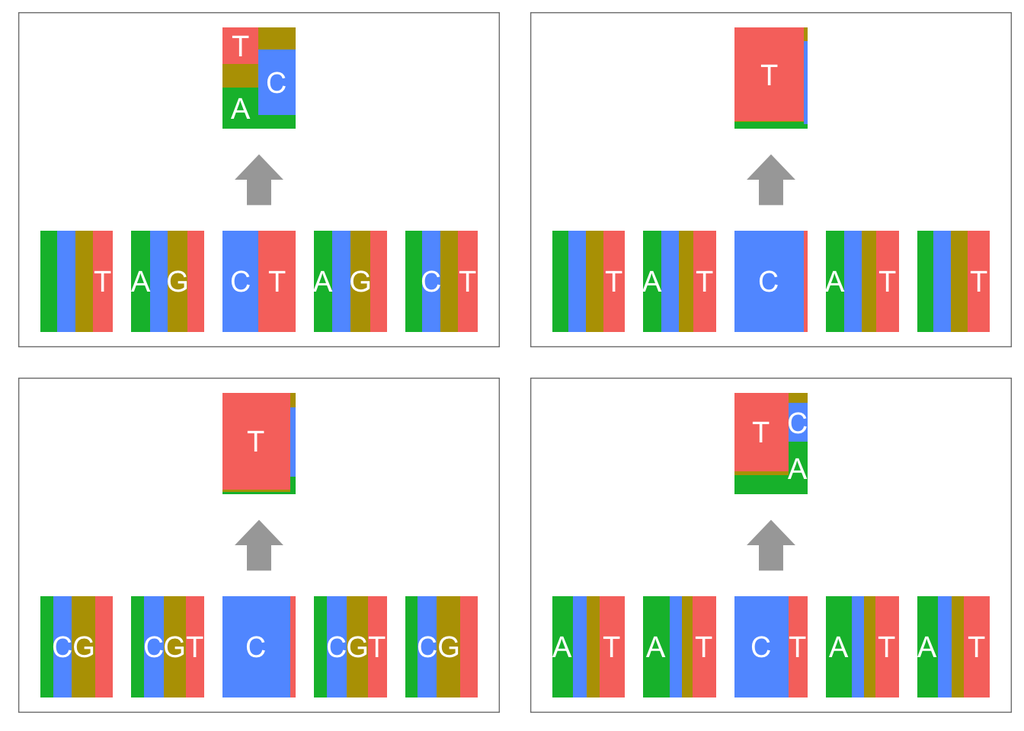

```r
theta <- topics_clus$clust_4$theta;
omega <- topics_clus$clust_4$omega

isBG <- TRUE
numBases <- 5
type <- "independent"
flankingBasesNum = as.integer(numBases)
trDir <- FALSE
fdim <- c(6, rep(4, numBases - 1), rep(2, as.integer(trDir)))
sample_names <- rownames(signature_counts)


K <- dim(omega)[2]
F <- array(0, c(K, length(fdim), max(fdim)))
for(k in 1:K){
  for(kk in 1:length(fdim)){
    temp <- tapply(theta[,k], mut_features_mat[,kk], sum)
    F[k,kk,as.numeric(names(temp))] <- as.numeric(temp)
  }
}

Param <- new(Class = "EstimatedParameters",
           type = type,
           flankingBasesNum = flankingBasesNum,
           transcriptionDirection = trDir,
           possibleFeatures = as.integer(fdim),
           sampleList = sample_names,
           signatureNum = as.integer(K),
           isBackGround = isBG,
           signatureFeatureDistribution = F,
           sampleSignatureDistribution = omega,
           loglikelihood = -100000)

graphList <- list(mode="vector")
graphList[[1]] <- visPMSignature(Param, 1)
graphList[[2]] <- visPMSignature(Param, 2)
graphList[[3]] <- visPMSignature(Param, 3)
graphList[[4]] <- visPMSignature(Param, 4)
library(grid)
library(gridExtra)
do.call("grid.arrange",
          args = list(grobs=graphList,
                      ncol = 2,
                      nrow = 2))
```

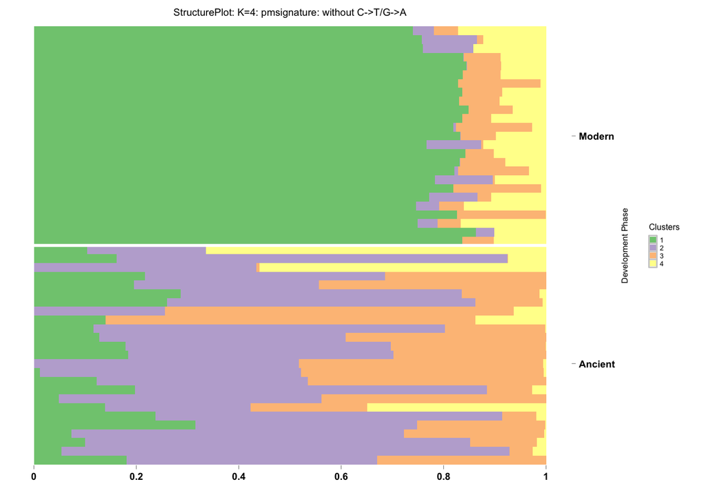

```r
omega <- slot(Param, "sampleSignatureDistribution")
library(CountClust)
annotation <- data.frame(
  sample_id = paste0("X", c(1:NROW(omega))),
  tissue_label = factor(c(rep("Ancient",25), rep("Modern",25)))
)

rownames(omega) <- annotation$sample_id;

StructureGGplot(omega = omega,
                annotation = annotation,
                palette = RColorBrewer::brewer.pal(8, "Accent"),
                yaxis_label = "Development Phase",
                order_sample = FALSE,
                figure_title = paste0("StructurePlot: K=", dim(omega)[2],": pmsignature: without C->T/G->A"),
                axis_tick = list(axis_ticks_length = .1,
                                 axis_ticks_lwd_y = .1,
                                 axis_ticks_lwd_x = .1,
                                 axis_label_size = 7,
                                 axis_label_face = "bold"))
```

```r
apply(ExtractTopFeatures(theta, top_features = 10, method="poisson", options="min"), c(1,2), function(x) signature_set[x])
```

```
##      [,1]       [,2]       [,3]       [,4]       [,5]       [,6]
## [1,] "GGT->GGG" "CTT->GTC" "GGT->CGT" "GGT->CGG" "AGT->CAG" "GGT->CAG"
## [2,] "ACC->TTT" "TTC->TCA" "AAC->TCC" "ACC->TAC" "TTC->TAG" "GAC->TTT"
## [3,] "GGC->TGG" "GGC->TCG" "CGC->TGG" "GCC->TGG" "GGC->TGC" "GGC->TGT"
## [4,] "AAT->AAA" "AAT->AGT" "TGT->AAA" "AGT->AAA" "AAT->ATA" "ATT->AAA"
##      [,7]       [,8]       [,9]       [,10]
## [1,] "CCT->CGG" "CAT->CGG" "GAT->CGG" "GGT->CCC"
## [2,] "TTC->TTG" "CAC->TCA" "CCC->TAA" "GTC->TTT"
## [3,] "GGC->TCC" "CCC->TGG" "CGC->TCG" "GCC->TGC"
## [4,] "AAT->AGA" "TAT->AAA" "AAT->AAT" "GAT->AAA"
```

### Conditional Damage results (CountCluster)

We also perform conditional damage signatures for $K=3$.

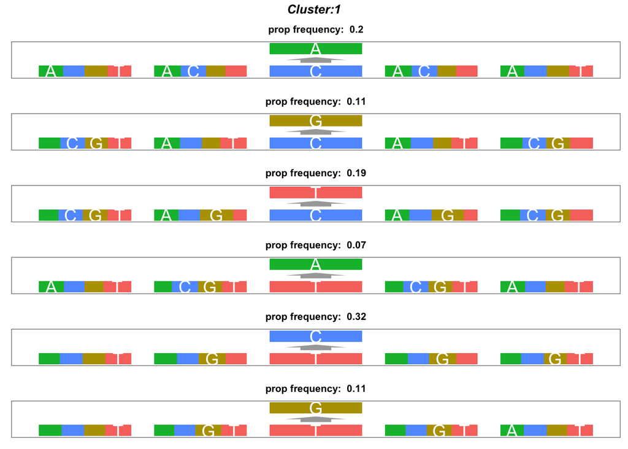

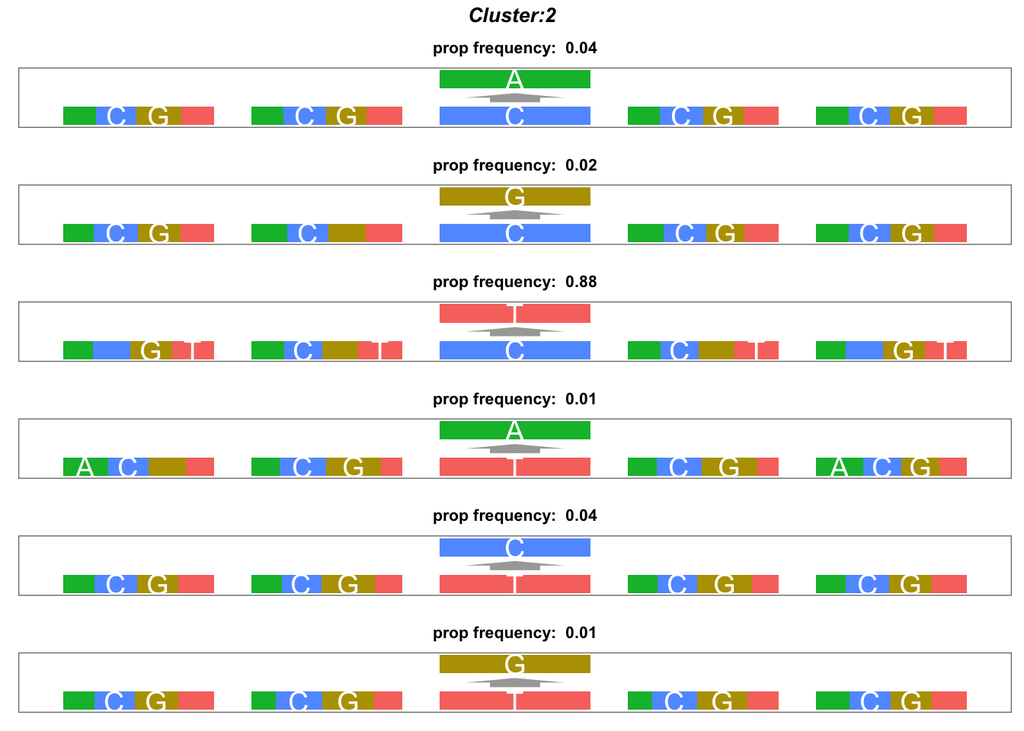

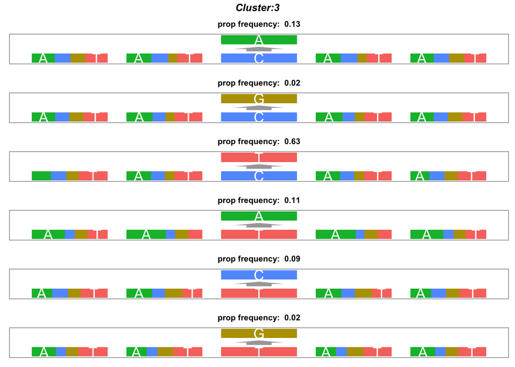

```r
theta <- topics_clus$clust_3$theta;
omega <- topics_clus$clust_3$omega

sample_names <- rownames(signature_counts)

isBG <- TRUE
numBases <- 5
type <- "independent"
flankingBasesNum = as.integer(numBases)
trDir <- FALSE
fdim <- c(6, rep(4, numBases - 1), rep(2, as.integer(trDir)))

index_sub <- c("C->A", "C->G", "C->T", "T->A", "T->C", "T->G")

visDMSignature (theta,
                index_sub,
                pattern=sub_pattern,
                mutation_features_matrix = mut_features_mat,
                sample_names,
                flankingBasesNum=as.integer(numBases),
                trDir,
                fdim,
                title_size=10,
                panel_title_size=10,
                panel_title_font=4,
                layout=c(6,1))
```

## Damage results after removing C -> T

```r
indices <- which(sig_split[,3]=="C" & sig_split[,6]=="T")
signature_counts_noCtoT <- signature_counts[,-indices];
signature_set_noCtoT <- signature_set[-indices];
substitute_sig_noCtoT <- substitute_sig[-indices];

sig_split_noCtoT <- sig_split[-indices,];

sub_pattern_noCtoT <- sub_pattern[-indices];
mut_features_mat_noCtoT <- mut_features_mat[-indices,];


voom_signature_counts_noCtoT <- t(limma::voom(t(signature_counts_noCtoT))$E);

### track the voom weights

voom_weights_noCtoT <- t(limma::voom(t(signature_counts_noCtoT))$weights);
```

### Principal Component Analysis

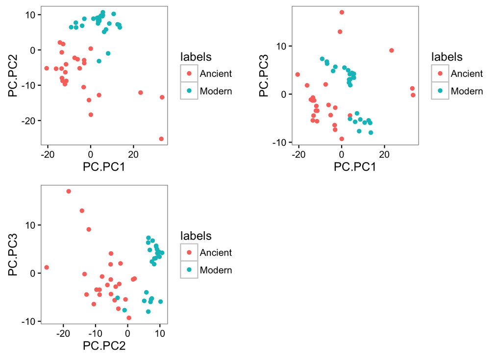

### Exploring substitution patterns

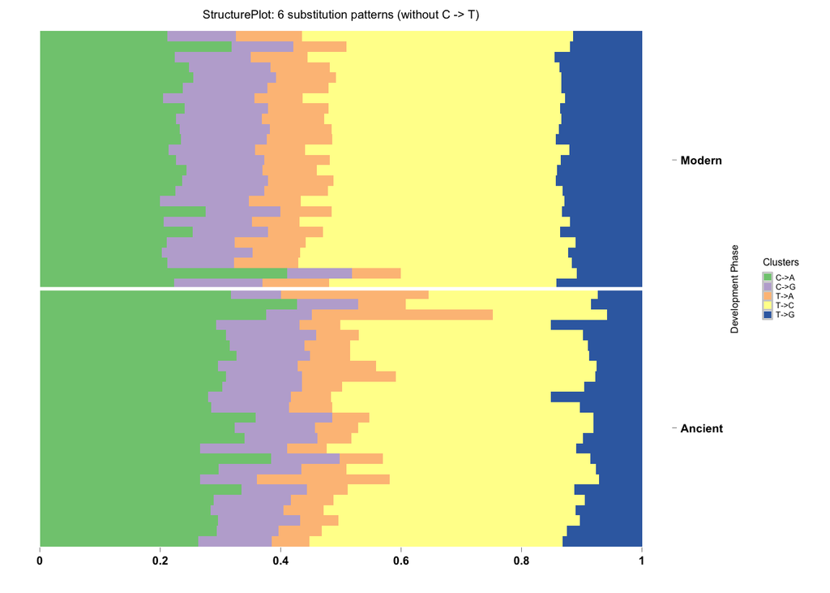

```r
normalize <- function(x) return(x/sum(x))
prop_substitute_sig_noCtoT <- do.call(rbind,
          lapply(1:dim(signature_counts_noCtoT)[1], function(x)
          normalize(tapply(signature_counts_noCtoT[x,], substitute_sig_noCtoT, sum))))

annotation <- data.frame(
  sample_id = paste0("X", c(1:NROW(prop_substitute_sig_noCtoT))),
  tissue_label = factor(c(rep("Ancient",25), rep("Modern",25)))
)

rownames(prop_substitute_sig_noCtoT) <- annotation$sample_id;

StructureGGplot(omega = prop_substitute_sig_noCtoT,
                annotation = annotation,
                palette = RColorBrewer::brewer.pal(8, "Accent"),
                yaxis_label = "Development Phase",
                order_sample = FALSE,
                figure_title = paste0("StructurePlot: 6 substitution patterns (without C -> T)"),
                axis_tick = list(axis_ticks_length = .1,
                                 axis_ticks_lwd_y = .1,
                                 axis_ticks_lwd_x = .1,
                                 axis_label_size = 7,
                                 axis_label_face = "bold"))
```

### Factor analysis (FLASH type=“constant”)

```r
ll <- flashpool(voom_signature_counts_noCtoT, K=10,
                 tol=1e-3, maxiter_r1 = 100,
                 partype="constant",
                 nonnegative=FALSE)
```

```
## We are at iteration 1
## We are at iteration 2
## We are at iteration 3
## We are at iteration 4
## We are at iteration 5
## We are at iteration 6
## We are at iteration 7
## We are at iteration 8
## We are at iteration 9
## We are at iteration 10
```

```r
postprocess_ll <- flash_factor_postprocess(ll$l,ll$f, voom_signature_counts_noCtoT)
pve_percentage <- c("", paste0(": PVE : ", round(postprocess_ll$PVE*100,1), "%"))

annotation <- data.frame(
  sample_id = paste0("X", c(1:NROW(ll$l))),
  label = factor(c(rep("Ancient",25), rep("Modern",25)))
)

rownames(ll$l) <- annotation$sample_id;
```

```r
FactorGGBar(loadings = ll$l,
            annotation = annotation,
            palette = list("mid"="white",
                           "low"="red",
                           "high"="blue",
                           "midpoint"=0),
             yaxis_label = "Population Type",
             figure_title = " ",
             axis_tick = list(axis_ticks_length = .1,
                              axis_ticks_lwd_y = .1,
                              axis_ticks_lwd_x = .1,
                              axis_label_size = 7,
                              axis_label_face = "bold"),
            legend_labels = pve_percentage,
            scale=TRUE,
            panel=list(panel_rows=2,
                       panel_title="greedy FLASH Factor Loadings Bar plot (without C to T)",
                       panel_title_fontsize=10,
                       panel_title_font=3))
```

[output not shown]

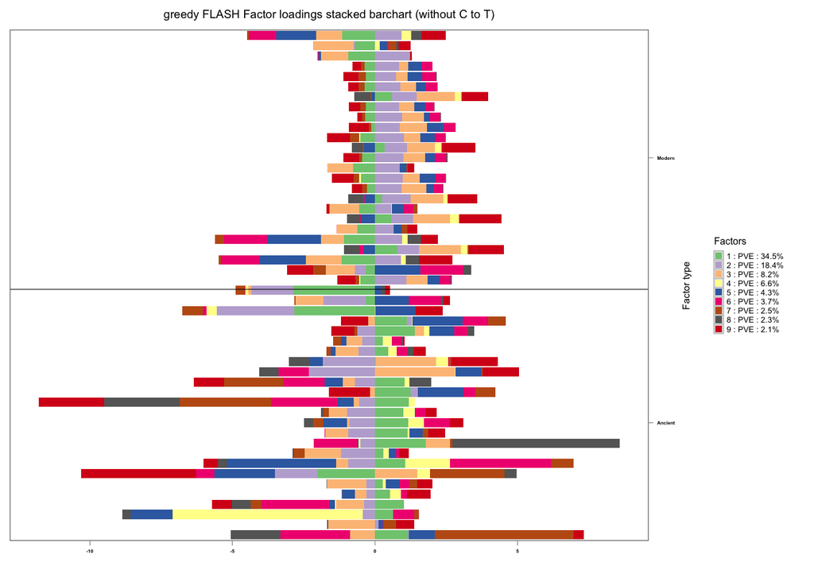

```r
FactorGGplot(loadings = ll$l[,-1],
             annotation = annotation,
             palette = c( RColorBrewer::brewer.pal(8, "Accent"),
                          RColorBrewer::brewer.pal(4, "Spectral")),
             figure_title = "greedy FLASH Factor loadings stacked barchart (without C to T)",
             yaxis_label = "Factor type",
             order_sample = FALSE,
             sample_order_decreasing = TRUE,
             split_line = list(split_lwd = 0.2,
                               split_col = "black"),
             plot_labels = TRUE,
             legend_labels = pve_percentage[-1],
             scale=TRUE,
             axis_tick = list(axis_ticks_length = .1,
                              axis_ticks_lwd_y = .1,
                              axis_ticks_lwd_x = .1,
                              axis_label_size = 3,
                              axis_label_face = "bold"))
```

```r
rownames(ll$f) <- signature_set_noCtoT
ll_f_scale <- apply(ll$f,2,function(x)
                                  {
                                      if(sd(x)!=0) {return (x/sd(x))}
                                      else {return (x)}
    })

normalize <- function(x) { return (x/sum(x))}

abs_f_scale <- apply(ll$f,2,function(x) normalize(abs(x)))
indices <- CountClust::ExtractTopFeatures(abs_f_scale, top_features=10, method="poisson", options="min")
imp_features <- apply(indices, c(1,2), function(x) signature_set[x])

imp_features
```

```
##       [,1]       [,2]       [,3]       [,4]       [,5]       [,6]
##  [1,] "TAT->CTC" "GTC->TCA" "ACC->TCA" "AGT->CTG" "CGC->TCC" "TAC->GGT"
##  [2,] "AAC->TTT" "AGT->GAT" "GGC->TGT" "GGC->TAA" "AAC->TAT" "AGT->GAA"
##  [3,] "TCC->GAC" "CAC->AAA" "GAC->TTC" "CAC->ATA" "CTT->AAA" "CCT->GGT"
##  [4,] "AGT->ATT" "AGT->ATA" "GCC->GAT" "AGT->AAT" "TAT->AAT" "GGC->ATG"
##  [5,] "GAC->AAC" "CTC->GAG" "GCC->TTC" "GTT->GAG" "CGT->GAT" "CGC->AAG"
##  [6,] "GCT->AGA" "ATT->GCT" "CCC->TTG" "ATC->ACG" "GCT->CGT" "ATT->GCA"
##  [7,] "GTT->AGG" "CCC->TAT" "CGC->GGT" "GCC->ATT" "TAC->ACC" "AAC->GTC"
##  [8,] "GCT->AGC" "CCC->TTC" "ATC->GGG" "AGT->CAT" "TAT->CAA" "CCC->TGC"
##  [9,] "GGT->CGC" "ACT->ACA" "GGC->TGA" "AGT->CGC" "GGT->CGG" "ACC->GTA"
## [10,] "AGT->GCC" "ACC->AAT" "ACC->ACT" "GGC->GGC" "CGC->GCT" "GGC->GCT"
##       [,7]       [,8]       [,9]       [,10]
##  [1,] "CGC->AAA" "TAT->CTG" "GTC->ATT" "ACC->ATT"
##  [2,] "AAC->TAA" "ATT->CTA" "ATT->CAT" "GGC->TAC"
##  [3,] "ACT->CTC" "CTC->TTA" "CTT->ATG" "CTT->ACA"
##  [4,] "CTT->GAC" "GGC->ATT" "GGT->ATA" "AAT->GAT"
##  [5,] "ATT->AGT" "ACC->ATG" "AAC->GGA" "GTC->ACC"
##  [6,] "GGT->ATC" "GTC->TAT" "CAT->CAA" "AGT->GGT"
##  [7,] "AAT->CGA" "ATT->GGA" "GCT->GAC" "GAC->ATA"
##  [8,] "GTT->ATC" "GAC->GAG" "CTC->ATG" "GAC->GGT"
##  [9,] "CCT->CAT" "CTT->GTG" "CAT->AGT" "CTC->ATT"
## [10,] "CCT->ATG" "TAT->GTT" "TAT->AGC" "CTT->GCA"
```

### Factor analysis (FLASH type=“known”)

```r
ll <- flashpool(voom_signature_counts_noCtoT, K=10,
                 tol=1e-3, maxiter_r1 = 100,
                 partype="known",
                 sigmae2_true = 1/(voom_weights_noCtoT),
                 nonnegative=FALSE)
```

```
## We are at iteration 1
## We are at iteration 2
## We are at iteration 3
## We are at iteration 4
## We are at iteration 5
## We are at iteration 6
## We are at iteration 7
## We are at iteration 8
## We are at iteration 9
## We are at iteration 10
```

```r
postprocess_ll <- flash_factor_postprocess(ll$l,ll$f, voom_signature_counts_noCtoT)
pve_percentage <- c("", paste0(": PVE : ", round(postprocess_ll$PVE*100,1), "%"))

zero_pve <- max(which(postprocess_ll$PVE > 0))
ll$l <- ll$l[,1:(1+zero_pve)]
ll$f <- ll$f[,1:(1+zero_pve)]

annotation <- data.frame(
  sample_id = paste0("X", c(1:NROW(ll$l))),
  label = factor(c(rep("Ancient",25), rep("Modern",25)))
)

rownames(ll$l) <- annotation$sample_id;
```

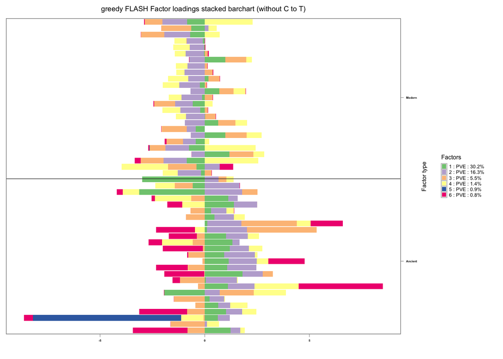

```r
FactorGGplot(loadings = ll$l[,-1],
             annotation = annotation,
             palette = c( RColorBrewer::brewer.pal(8, "Accent"),
                          RColorBrewer::brewer.pal(4, "Spectral")),
             figure_title = "greedy FLASH Factor loadings stacked barchart (without C to T)",
             yaxis_label = "Factor type",
             order_sample = FALSE,
             sample_order_decreasing = TRUE,
             split_line = list(split_lwd = 0.2,
                               split_col = "black"),
             plot_labels = TRUE,
             legend_labels = pve_percentage[-1],
             scale=TRUE,
             axis_tick = list(axis_ticks_length = .1,
                              axis_ticks_lwd_y = .1,
                              axis_ticks_lwd_x = .1,
                              axis_label_size = 3,
                              axis_label_face = "bold"))
```

```r
rownames(ll$f) <- signature_set_noCtoT
ll_f_scale <- apply(ll$f,2,function(x)
                                  {
                                      if(sd(x)!=0) {return (x/sd(x))}
                                      else {return (x)}
    })

normalize <- function(x) { return (x/sum(x))}

abs_f_scale <- apply(ll$f,2,function(x) normalize(abs(x)))
indices <- CountClust::ExtractTopFeatures(abs_f_scale, top_features=10, method="poisson", options="min")
imp_features <- apply(indices, c(1,2), function(x) signature_set[x])

imp_features
```

```
##      [,1]       [,2]       [,3]       [,4]       [,5]       [,6]
## [1,] "ACC->TCT" "CGT->GAG" "TAT->CTG" "CGC->ATT" "TAT->CTC" "GTC->TCA"
## [2,] "ACC->GAT" "ATT->CTT" "AGT->GAT" "AAC->TTT" "GGC->TCT" "CGC->GAT"
## [3,] "CCC->ATC" "CAC->AAA" "CAC->ATA" "ACT->CTC" "CTT->ATC" "CAC->AAC"
## [4,] "CTT->GAG" "CTC->ACG" "CTT->GAC" "AAC->TCG" "ATT->CCG" "GAT->CAC"
## [5,] "AAT->AGC" "CCT->AAA" "GGC->GCG" "ATT->GTG" "AGC->GAG" "AGC->GTA"
## [6,] "GCC->TTC" "CTC->GAG" "GTC->ACC" "TAT->CCC" "AGT->ACT" "GGC->GTC"
## [7,] "GGC->GAT" "AGC->ATC" "CGC->GGT" "CGC->GGA" "GTT->AGG" "AGT->GGA"
##      [,7]       [,8]       [,9]       [,10]
## [1,] "ATT->ATG" "CGC->ATG" "CAT->CCA" "TAC->GGT"
## [2,] "TAT->GAC" "GGC->TAT" "GCC->TGC" "ATT->CTG"
## [3,] "CCC->ATA" "GAC->TTC" "ATC->GTG" "GAC->TTG"
## [4,] "CTC->ACC" "ATT->CGC" "CCC->GGT" "CTC->AAC"
## [5,] "GTT->ACT" "ATT->GGT" "ATT->GCT" "CTT->CAT"
## [6,] "GTT->GAG" "CGC->AAG" "CGT->GAT" "GCT->CCG"
## [7,] "GCC->ATT" "AGC->ATA" "GGT->CAT" "AGC->ATT"
```

### CountCluster application

```r
topics_clus <- get(load("../rda/CountClust_output_Lindo2016_without_C_to_T.rda"))
```

#### K=2

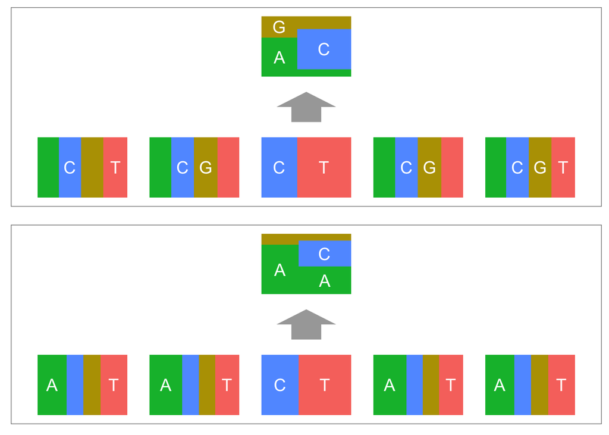

```r
theta <- topics_clus$clust_2$theta;
omega <- topics_clus$clust_2$omega

isBG <- TRUE
numBases <- 5
type <- "independent"
flankingBasesNum = as.integer(numBases)
trDir <- FALSE
sample_names <- rownames(signature_counts_noCtoT)
fdim <- c(6, rep(4, numBases - 1), rep(2, as.integer(trDir)))


K <- dim(omega)[2]
F <- array(0, c(K, length(fdim), max(fdim)))
for(k in 1:K){
  for(kk in 1:length(fdim)){
    temp <- tapply(theta[,k], mut_features_mat_noCtoT[,kk], sum)
    F[k,kk,as.numeric(names(temp))] <- as.numeric(temp)
  }
}


Param <- new(Class = "EstimatedParameters",
           type = type,
           flankingBasesNum = flankingBasesNum,
           transcriptionDirection = trDir,
           possibleFeatures = as.integer(fdim),
           sampleList = sample_names,
           signatureNum = as.integer(K),
           isBackGround = isBG,
           signatureFeatureDistribution = F,
           sampleSignatureDistribution = omega,
           loglikelihood = -100000)

graphList <- list(mode="vector")
graphList[[1]] <- visPMSignature(Param, 1)
graphList[[2]] <- visPMSignature(Param, 2)
library(grid)
library(gridExtra)
do.call("grid.arrange",
          args = list(grobs=graphList,
                      ncol = 1,
                      nrow = 2))
```

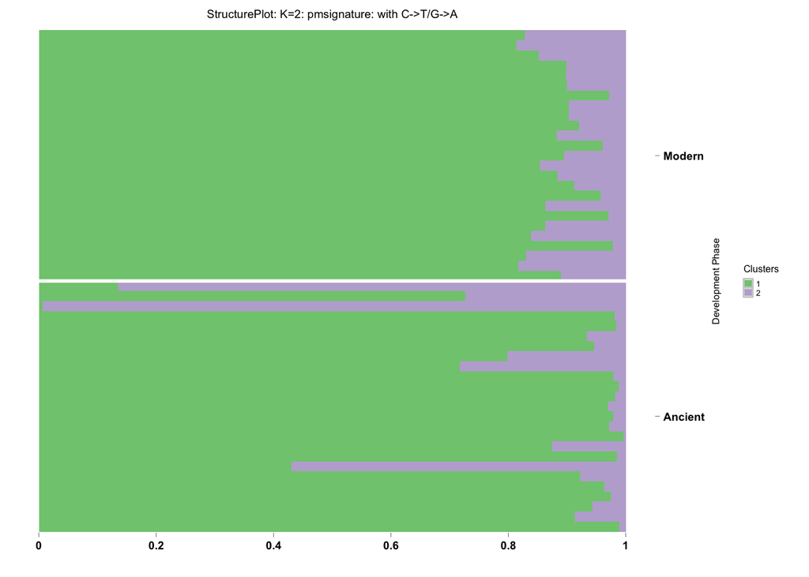

```r
omega <- slot(Param, "sampleSignatureDistribution")
library(CountClust)
annotation <- data.frame(
  sample_id = paste0("X", c(1:NROW(omega))),
  tissue_label = factor(c(rep("Ancient",25), rep("Modern",25)))
)

rownames(omega) <- annotation$sample_id;

StructureGGplot(omega = omega,
                annotation = annotation,
                palette = RColorBrewer::brewer.pal(8, "Accent"),
                yaxis_label = "Development Phase",
                order_sample = FALSE,
                figure_title = paste0("StructurePlot: K=", dim(omega)[2],": pmsignature: with C->T/G->A"),
                axis_tick = list(axis_ticks_length = .1,
                                 axis_ticks_lwd_y = .1,
                                 axis_ticks_lwd_x = .1,
                                 axis_label_size = 7,
                                 axis_label_face = "bold"))
```

```r
apply(ExtractTopFeatures(theta, top_features = 10, method="poisson", options="min"), c(1,2), function(x) signature_set_noCtoT[x])
```

```
##      [,1]       [,2]       [,3]       [,4]       [,5]       [,6]
## [1,] "GGT->GGG" "GGT->CGG" "CCT->CGG" "CGT->CCG" "GCT->CGC" "GCT->CGG"
## [2,] "AAT->AAA" "AAT->AGT" "TGT->AAA" "AAT->ATA" "AAT->ACG" "ATT->AAA"
##      [,7]       [,8]       [,9]       [,10]
## [1,] "GGT->CCC" "CGT->CCC" "GGT->CCG" "CCC->GGG"
## [2,] "TAT->AAA" "AAT->AAT" "AGT->AAA" "AAT->AGA"
```

#### K=3

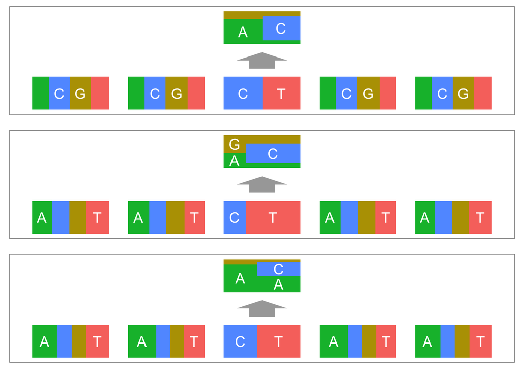

```r
theta <- topics_clus$clust_3$theta;
omega <- topics_clus$clust_3$omega

isBG <- TRUE
numBases <- 5
type <- "independent"
flankingBasesNum = as.integer(numBases)
trDir <- FALSE
fdim <- c(6, rep(4, numBases - 1), rep(2, as.integer(trDir)))
sample_names <- rownames(signature_counts_noCtoT)

K <- dim(omega)[2]
F <- array(0, c(K, length(fdim), max(fdim)))
for(k in 1:K){
  for(kk in 1:length(fdim)){
    temp <- tapply(theta[,k], mut_features_mat_noCtoT[,kk], sum)
    F[k,kk,as.numeric(names(temp))] <- as.numeric(temp)
  }
}

Param <- new(Class = "EstimatedParameters",
           type = type,
           flankingBasesNum = flankingBasesNum,
           transcriptionDirection = trDir,
           possibleFeatures = as.integer(fdim),
           sampleList = sample_names,
           signatureNum = as.integer(K),
           isBackGround = isBG,
           signatureFeatureDistribution = F,
           sampleSignatureDistribution = omega,
           loglikelihood = -100000)

graphList <- list(mode="vector")
graphList[[1]] <- visPMSignature(Param, 1)
graphList[[2]] <- visPMSignature(Param, 2)
graphList[[3]] <- visPMSignature(Param, 3)
library(grid)
library(gridExtra)
do.call("grid.arrange",
          args = list(grobs=graphList,
                      ncol = 1,
                      nrow = 3))
```

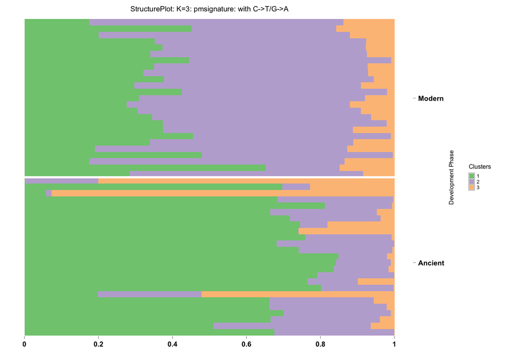

```r
omega <- slot(Param, "sampleSignatureDistribution")
library(CountClust)
annotation <- data.frame(
  sample_id = paste0("X", c(1:NROW(omega))),
  tissue_label = factor(c(rep("Ancient",25), rep("Modern",25)))
)

rownames(omega) <- annotation$sample_id;

StructureGGplot(omega = omega,
                annotation = annotation,
                palette = RColorBrewer::brewer.pal(8, "Accent"),
                yaxis_label = "Development Phase",
                order_sample = FALSE,
                figure_title = paste0("StructurePlot: K=", dim(omega)[2],": pmsignature: with C->T/G->A"),
                axis_tick = list(axis_ticks_length = .1,
                                 axis_ticks_lwd_y = .1,
                                 axis_ticks_lwd_x = .1,
                                 axis_label_size = 7,
                                 axis_label_face = "bold"))
```

```r
apply(ExtractTopFeatures(theta, top_features = 10, method="poisson", options="min"), c(1,2), function(x) signature_set_noCtoT[x])
```

```
##      [,1]       [,2]       [,3]       [,4]       [,5]       [,6]
## [1,] "GGC->AGG" "GGC->ACC" "CCC->AGG" "CGC->ACG" "GCC->AGC" "CGC->ACC"
## [2,] "CTT->GTC" "TTT->GAC" "CAT->GGT" "TGT->GAC" "CTC->GTC" "GGT->ACA"
## [3,] "AAT->AAA" "AAT->AGT" "TGT->AAA" "AAT->ATA" "AGT->AAA" "ATT->AAA"
##      [,7]       [,8]       [,9]       [,10]
## [1,] "GGC->ACG" "CGC->AGG" "CCC->AGC" "GCC->AGG"
## [2,] "ACT->CTG" "CTT->GTT" "GTT->CTT" "TTT->GCT"
## [3,] "AAT->AAT" "AAT->AGA" "TAT->AAA" "GAT->AAA"
```

#### K=4

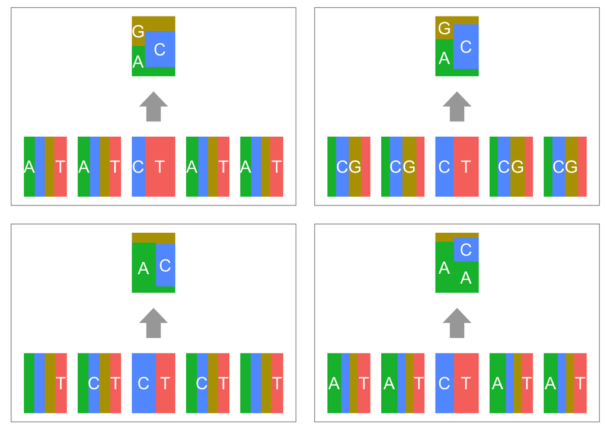

```r
theta <- topics_clus$clust_4$theta;
omega <- topics_clus$clust_4$omega

isBG <- TRUE
numBases <- 5
type <- "independent"
flankingBasesNum = as.integer(numBases)
trDir <- FALSE
fdim <- c(6, rep(4, numBases - 1), rep(2, as.integer(trDir)))
sample_names <- rownames(signature_counts_noCtoT)


K <- dim(omega)[2]
F <- array(0, c(K, length(fdim), max(fdim)))
for(k in 1:K){
  for(kk in 1:length(fdim)){
    temp <- tapply(theta[,k], mut_features_mat_noCtoT[,kk], sum)
    F[k,kk,as.numeric(names(temp))] <- as.numeric(temp)
  }
}

Param <- new(Class = "EstimatedParameters",
           type = type,
           flankingBasesNum = flankingBasesNum,
           transcriptionDirection = trDir,
           possibleFeatures = as.integer(fdim),
           sampleList = sample_names,
           signatureNum = as.integer(K),
           isBackGround = isBG,
           signatureFeatureDistribution = F,
           sampleSignatureDistribution = omega,
           loglikelihood = -100000)

graphList <- list(mode="vector")
graphList[[1]] <- visPMSignature(Param, 1)
graphList[[2]] <- visPMSignature(Param, 2)
graphList[[3]] <- visPMSignature(Param, 3)
graphList[[4]] <- visPMSignature(Param, 4)
library(grid)
library(gridExtra)
do.call("grid.arrange",
          args = list(grobs=graphList,
                      ncol = 2,
                      nrow = 2))
```

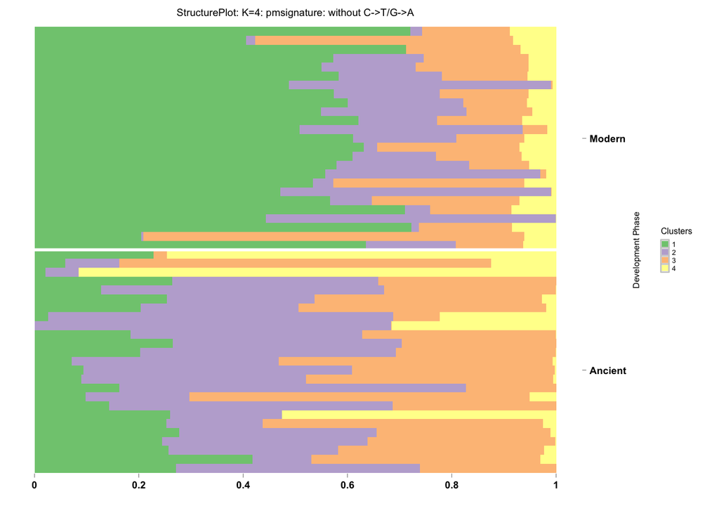

```r
omega <- slot(Param, "sampleSignatureDistribution")
library(CountClust)
annotation <- data.frame(
  sample_id = paste0("X", c(1:NROW(omega))),
  tissue_label = factor(c(rep("Ancient",25), rep("Modern",25)))
)

rownames(omega) <- annotation$sample_id;

StructureGGplot(omega = omega,
                annotation = annotation,
                palette = RColorBrewer::brewer.pal(8, "Accent"),
                yaxis_label = "Development Phase",
                order_sample = FALSE,
                figure_title = paste0("StructurePlot: K=", dim(omega)[2],": pmsignature: without C->T/G->A"),
                axis_tick = list(axis_ticks_length = .1,
                                 axis_ticks_lwd_y = .1,
                                 axis_ticks_lwd_x = .1,
                                 axis_label_size = 7,
                                 axis_label_face = "bold"))
```

```r
apply(ExtractTopFeatures(theta, top_features = 10, method="poisson", options="min"), c(1,2), function(x) signature_set_noCtoT[x])
```

```
##      [,1]       [,2]       [,3]       [,4]       [,5]       [,6]
## [1,] "CTT->GTC" "TTT->GAC" "TTT->GTA" "GTT->CTT" "AAT->GAC" "CAT->GAA"
## [2,] "GGT->CGG" "GCT->CGC" "CGT->CCG" "GCT->CGG" "GGT->CGC" "CGT->CCC"
## [3,] "ACC->ACC" "CCC->ACT" "TCC->ACC" "CCC->ACA" "GTC->AGG" "CAC->ACC"
## [4,] "AAT->AAA" "AAT->AGT" "TGT->AAA" "AAT->ATA" "ATT->AAA" "AAT->AAT"
##      [,7]       [,8]       [,9]       [,10]
## [1,] "ACT->GTT" "CAT->GTA" "ATT->GAC" "TTT->CTT"
## [2,] "GGT->CCG" "CCC->GGG" "CGT->CGG" "GGT->CCC"
## [3,] "GGC->ATG" "CCC->AAG" "TCC->ACT" "CCC->ATG"
## [4,] "TAT->AAA" "AGT->AAA" "AAT->AGA" "GAT->AAA"
```

### Conditional Damage results (CountCluster)

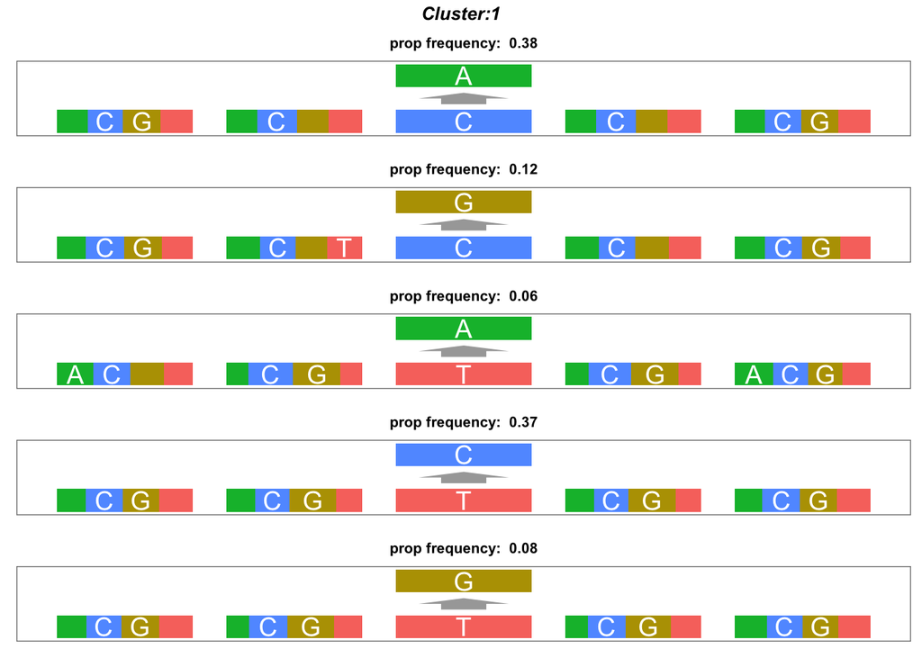

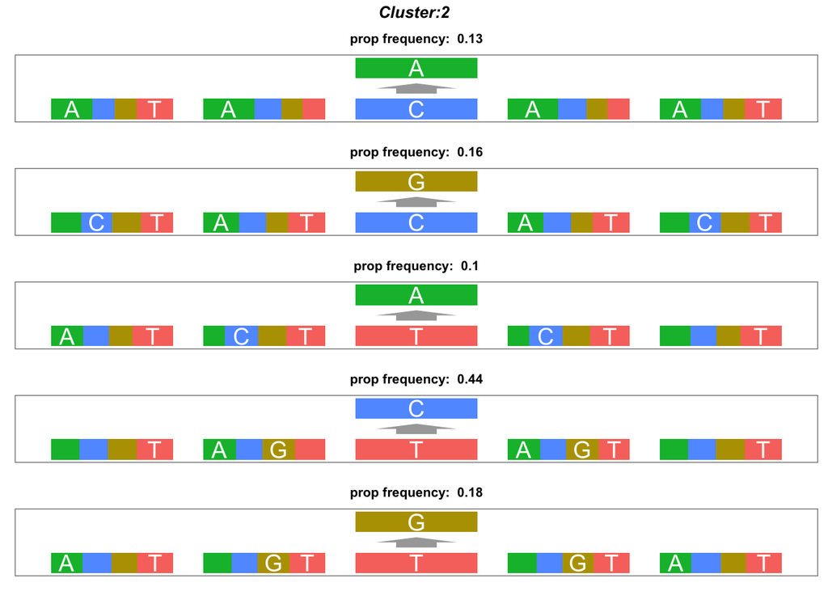

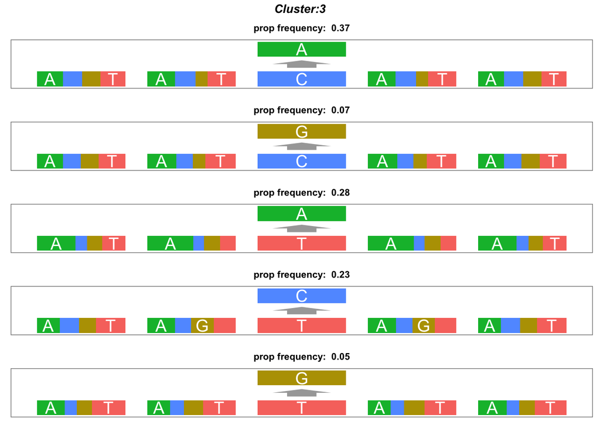

```r
theta <- topics_clus$clust_3$theta;
omega <- topics_clus$clust_3$omega

sample_names <- rownames(signature_counts_noCtoT)

isBG <- TRUE
numBases <- 5
type <- "independent"
flankingBasesNum = as.integer(numBases)
trDir <- FALSE
fdim <- c(6, rep(4, numBases - 1), rep(2, as.integer(trDir)))

index_sub <- c("C->A", "C->G", "T->A", "T->C", "T->G")
visDMSignature (theta,
                index_sub,
                pattern=sub_pattern_noCtoT,
                mutation_features_matrix = mut_features_mat_noCtoT,
                sample_names,
                flankingBasesNum=as.integer(numBases),
                trDir,
                fdim,
                title_size=10,
                panel_title_size=10,
                panel_title_font=4,
                layout=c(5,1))
```